# Exercices Lecture 5

Paolo Crosetto

9/12/2019

# Intro

Jusque là on a utilisé R pour *manipuler* et representer graphiquement* des *jeux de données* (en langage R, des `data.frame`). Mais R est né et a été développé pincipalement comme un langage de *statistique*. Aujourd’hui on va donc s’occuper de cela: comment faire des statistiques simples (correlation, model linéaire, test statistique) avec R.

Pour chaque commande / outil statistique qu’on couvrira aujourd’hui, l’exposition va se diviser en deux parties:

1. **statistiques avec base R**. Pour faire des stats on va abandonner de façon temporaire le *tidyverse* et utiliser le système R de base. En soi cela ne vous changera pas grand chose, mais vous verrez que les résultats des différentes fonctions (tests, régressions, etc…) ne sont aps dans un format *tidy* – n’ont pas une variable par colonne et une observation par ligne – et ne sont donc pas prêts tout de suite à être utilisés avec ce qu’on a appris jusque là (filter, select, ggplot…).
2. **lien stats de base -> tidyverse**. Heureusement il y a des solutions. On va donc explorer le package `broom` qui permet de ‘faire le ménage’ (broom signifie *balai* en anglais) et de transofrmer les résultats des régressions en data.frames bien ordonnés, qu’on pourra utiliser pour, par exemple, visualiser les résultats de façon graphique. On pourra aussi utiliser la puissance du `%>%` et de `group_by()` pour mettre en place de façon rapide des analyses par groupe et les visualiser.

# Régression linéaire.

## Base R

> utilisez les données `airquality` – il s’agit de la qualité de l’air à NYC sur un certian interval de temps en 1973. estimez une régression linéaire qui explique le niveau d’Ozone par la température, le vent et la radiation solaire. sauvegardez le résultat de la régression dans un objet, `firstreg`.

```r
  firstreg <- lm(Ozone ~ Solar.R + Wind + Temp, data = airquality)
```

> explorez `firstreg` dans votre environnement. Il y a beaucoup de sous objets et sous parties. Essayez de visualiser le tableau récapitulatif. Utilisez `summary`

```r
summary(firstreg)
```

```
##
## Call:
## lm(formula = Ozone ~ Solar.R + Wind + Temp, data = airquality)
##
## Residuals:
##     Min      1Q  Median      3Q     Max
## -40.485 -14.219  -3.551  10.097  95.619
##
## Coefficients:
##              Estimate Std. Error t value Pr(>|t|)
## (Intercept) -64.34208   23.05472  -2.791  0.00623 **
## Solar.R       0.05982    0.02319   2.580  0.01124 *
## Wind         -3.33359    0.65441  -5.094 1.52e-06 ***
## Temp          1.65209    0.25353   6.516 2.42e-09 ***
## ---
## Signif. codes:  0 '***' 0.001 '**' 0.01 '*' 0.05 '.' 0.1 ' ' 1
##
## Residual standard error: 21.18 on 107 degrees of freedom
##   (42 observations deleted due to missingness)
## Multiple R-squared:  0.6059, Adjusted R-squared:  0.5948
## F-statistic: 54.83 on 3 and 107 DF,  p-value: < 2.2e-16
```

> il y d’autres sous objets que vous pouvez explorer. Si vous plottez l’objet, cela donne tous les diagnostics de régression (on ne rentre pas dans les détails ici). Notez que les plots ne sont aps des ggplots, mais ont un air très différents; il s’agit des plot produits par Base R.

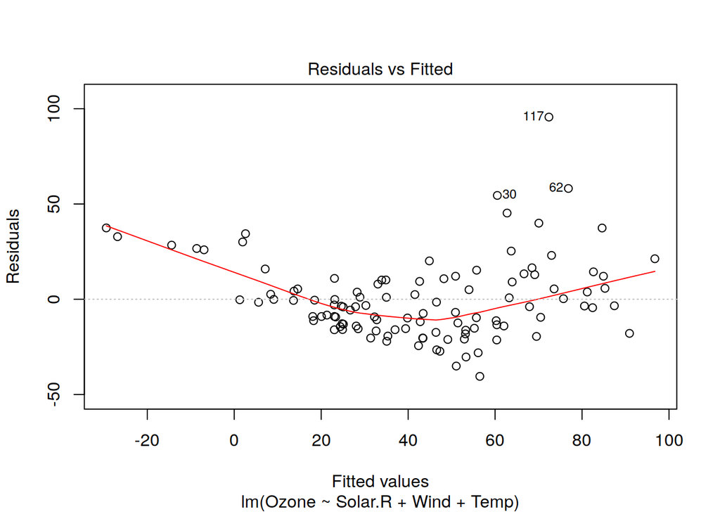

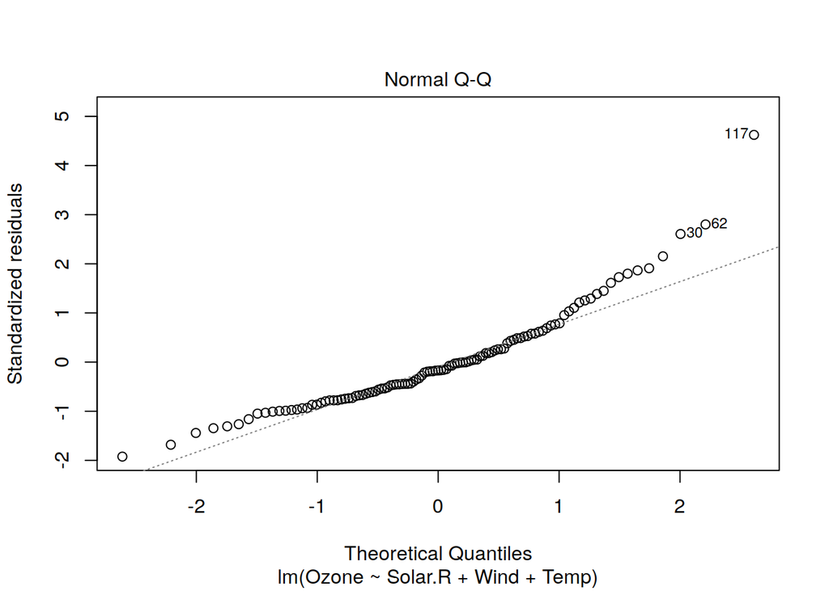

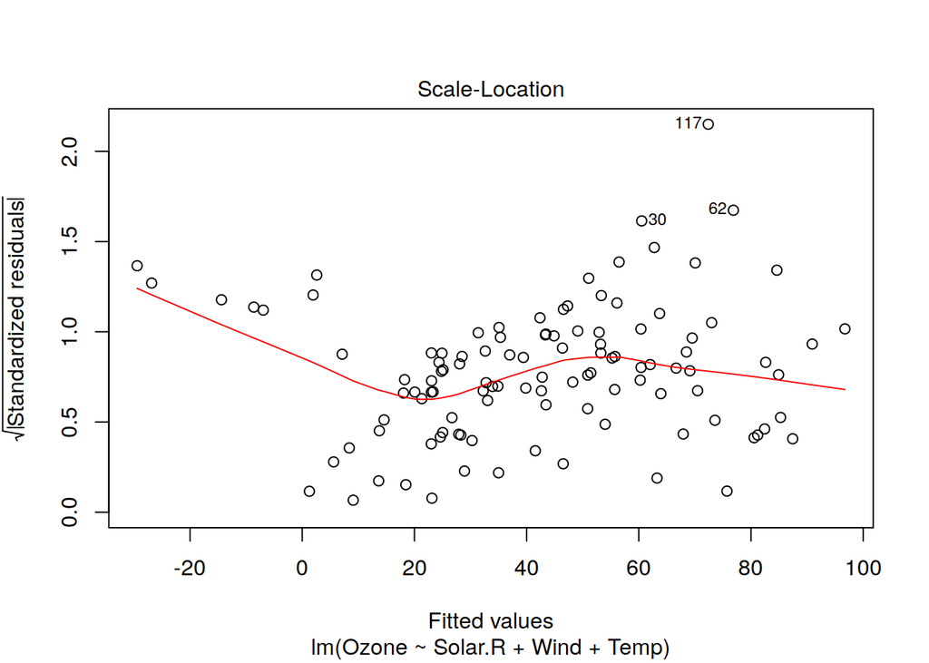

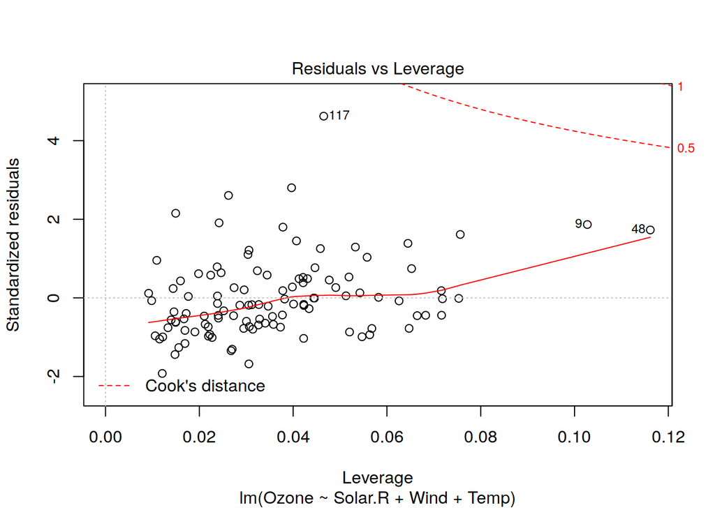

```r
plot(firstreg)
```

> vous pouvez accéder au coéfficients avec la fonction `coef()`

```r
coef(firstreg)
```

```
##  (Intercept)      Solar.R         Wind         Temp
## -64.34207893   0.05982059  -3.33359131   1.65209291
```

### exercice

> faites une régression de Ozone sur Wind en utilisant Base R et affichez son `summary()`

```r
charles <- lm(Ozone ~ Wind, data = airquality)
summary(charles)
```

```
##
## Call:
## lm(formula = Ozone ~ Wind, data = airquality)
##
## Residuals:
##     Min      1Q  Median      3Q     Max
## -51.572 -18.854  -4.868  15.234  90.000
##
## Coefficients:
##             Estimate Std. Error t value Pr(>|t|)
## (Intercept)  96.8729     7.2387   13.38  < 2e-16 ***
## Wind         -5.5509     0.6904   -8.04 9.27e-13 ***
## ---
## Signif. codes:  0 '***' 0.001 '**' 0.01 '*' 0.05 '.' 0.1 ' ' 1
##
## Residual standard error: 26.47 on 114 degrees of freedom
##   (37 observations deleted due to missingness)
## Multiple R-squared:  0.3619, Adjusted R-squared:  0.3563
## F-statistic: 64.64 on 1 and 114 DF,  p-value: 9.272e-13
```

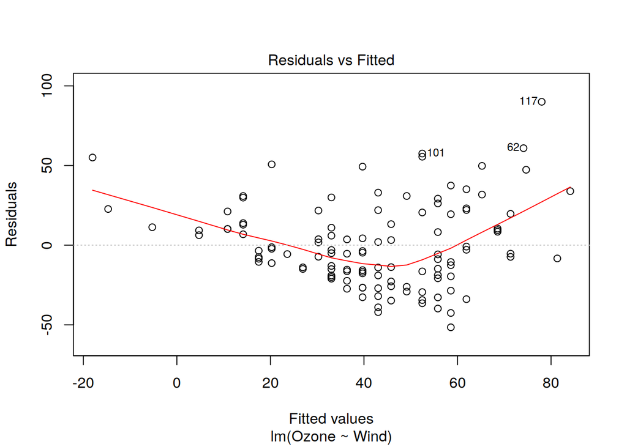

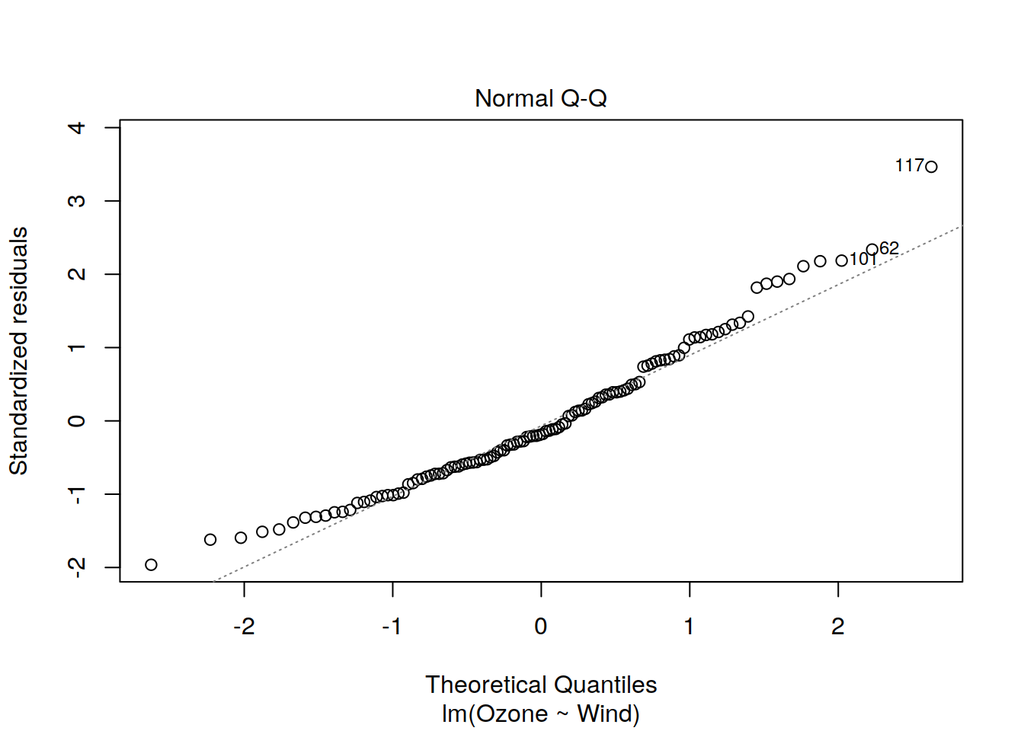

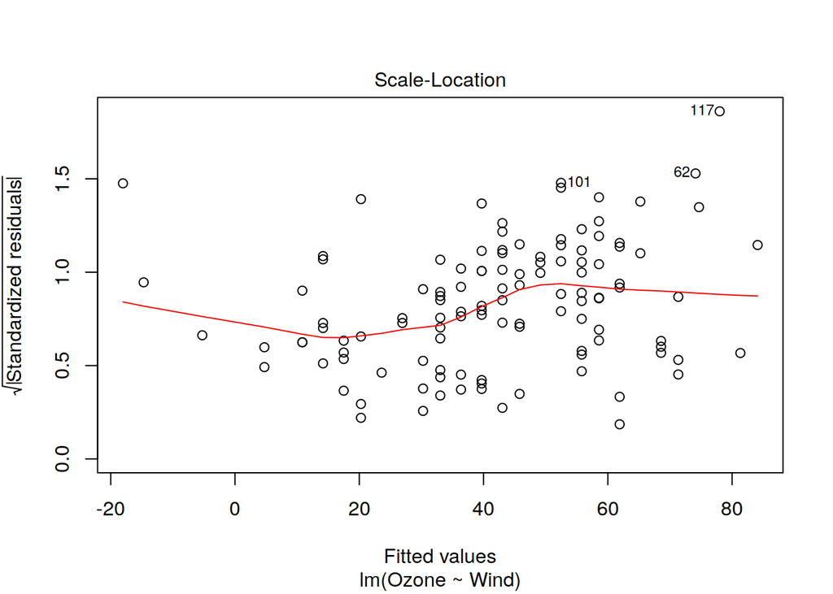

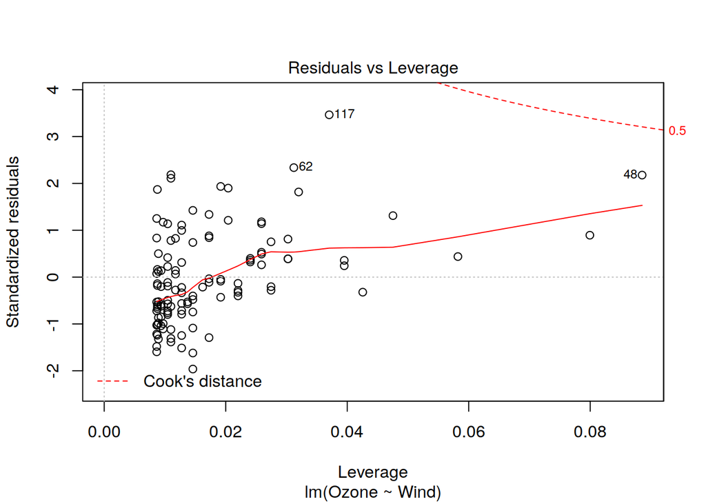

```r
plot(charles)
```

```r
coef(charles)
```

```
## (Intercept)        Wind
##   96.872895   -5.550923
```

## Broom

> tout cela n’est pas très pratique parce qu’on ne peut pas accéder aux données de la régression de façon *tidy*. On va donc utiliser `broom` pour le faire.

`broom` dispose de trois fonctions.

1. `tidy` retourne les coefficients, valeurs p et intervals de confiance de la régression en format data.frame.
2. `glance` retourne les indicateurs de diagnostic de la régression en format data.frame (sur une ligne)
3. `augment` retourne les données initiales ‘augmentées’ avec les valuers estimées par la régression.

### tidy

```r
airquality %>%
  lm(Ozone ~ Wind + Solar.R + Temp, data = .) %>%
  tidy() -> lmtidy
```

> et voilà, nos résultats sont maintenant en forme de data.frame et peuvent donc être utilisés pour nos analyses, plots… notamment: faites un plot des coefficients de la régression avec des barres d’erreur

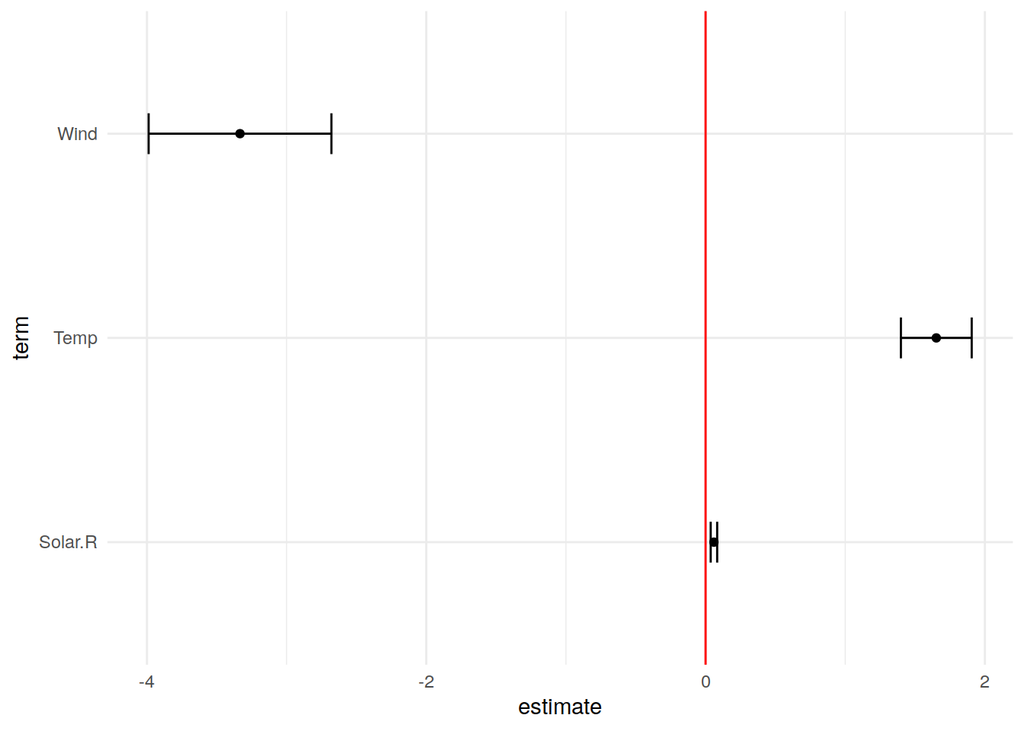

```r
lmtidy %>%
  filter(term != "(Intercept)") %>%
  ggplot(aes(x = term, y = estimate))+
  geom_point()+
  geom_errorbar(aes(ymin = estimate - std.error,
                    ymax = estimate + std.error), width = 0.2)+
  theme_minimal()+
  geom_hline(yintercept = 0, color = 'red')+
  coord_flip()
```

### 2. augment

`augment` ajoute les valuers estimées à notre data.frame. Cela nous permet, par exemple, de voir la régression de façon visuelle (sur deux variables uniquement) en plottant les points intiaux et les points estimés. On va faire cela par étapes, et pour la rélation Ozone ~ Temp

### 1. les points originaux de la rélation Ozone ~ Temp

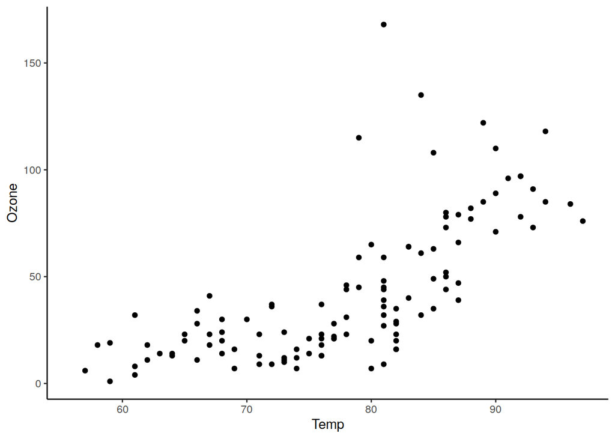

```r
airquality %>%
  ggplot(aes(x = Temp, y = Ozone))+
  geom_point()+
  theme_classic()
```

### 2. on ajoute les points estimés

(attention: ils seront sur une droite. Surpris?)

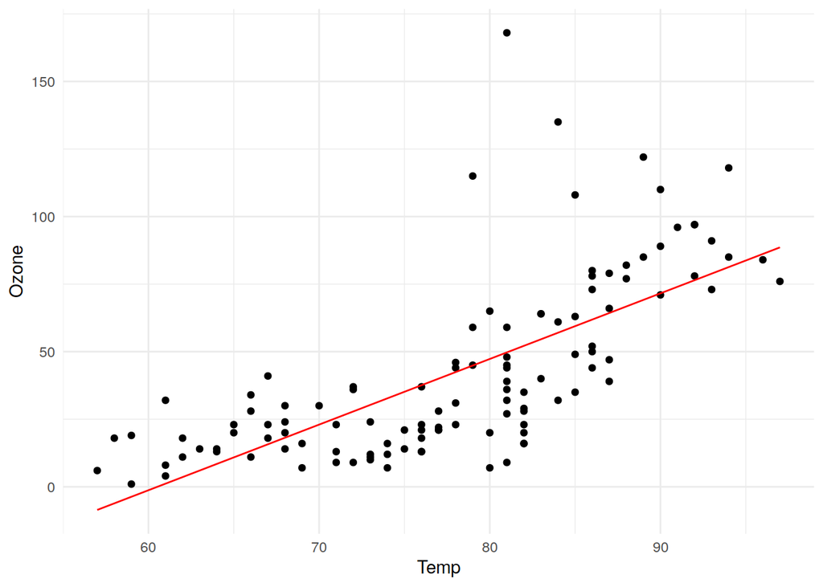

```r
airquality %>%
  lm(Ozone ~ Temp, data = .) %>%
  augment() %>%
  ggplot(aes(x = Temp, y = Ozone))+
  geom_point()+
  geom_line(aes(y = .fitted), color = 'red')+
  theme_minimal() -> plotreg
plotreg
```

Pour mieux visualiser les résidus on lie chaque point réel à sa prédiction par un `geom_segment()`

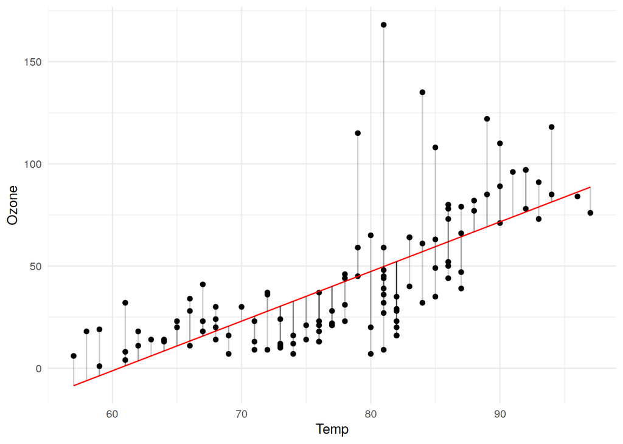

```r
plotreg +
  geom_segment(aes(x = Temp, xend = Temp, y = Ozone, yend = .fitted),
               alpha = 0.2)
```

### exercice

> faites une régression de Ozone sur Wind en utilisant le tidyverse et `tidy`

```r
airquality %>%
  lm(Ozone ~ Wind, data = .) %>%
  tidy()
```

```
## # A tibble: 2 x 5
##   term        estimate std.error statistic  p.value
##   <chr>          <dbl>     <dbl>     <dbl>    <dbl>
## 1 (Intercept)    96.9      7.24      13.4  3.99e-25
## 2 Wind           -5.55     0.690     -8.04 9.27e-13
```

### glance

glance est moins immédiatement utile mais le deviendra quand on pourra comparer différents modèles statistiques les uns à côté des autres. voilà ce que `glance()` donne

```r
airquality %>%
  lm(Ozone ~ Wind, data = .) %>%
  glance()
```

```
## # A tibble: 1 x 11
##   r.squared adj.r.squared sigma statistic  p.value    df logLik   AIC   BIC
##       <dbl>         <dbl> <dbl>     <dbl>    <dbl> <int>  <dbl> <dbl> <dbl>
## 1     0.362         0.356  26.5      64.6 9.27e-13     2  -544. 1093. 1101.
## # … with 2 more variables: deviance <dbl>, df.residual <int>
```

## La puissance du tidyverse: plusieurs régressions à la fois, par groupe

Avec le tidyverse on peut lancer plusieurs régressions à la fois, et en visualiser les résultats avec un seul ggplot. On va travailler avec la base de données `gapminder`.

### gapminder

gapminder est une base de données qui contient l’espérence de vie par pays sur plusieurs années. Il faut installer le package gapminder

```r
#install.packages("gapminder")
library(gapminder)
df <- gapminder
```

On va commencer par explorer les données. Comment l’espérance de vie a-t-elle évolué dans le temps pour tous les pays? un ggplot

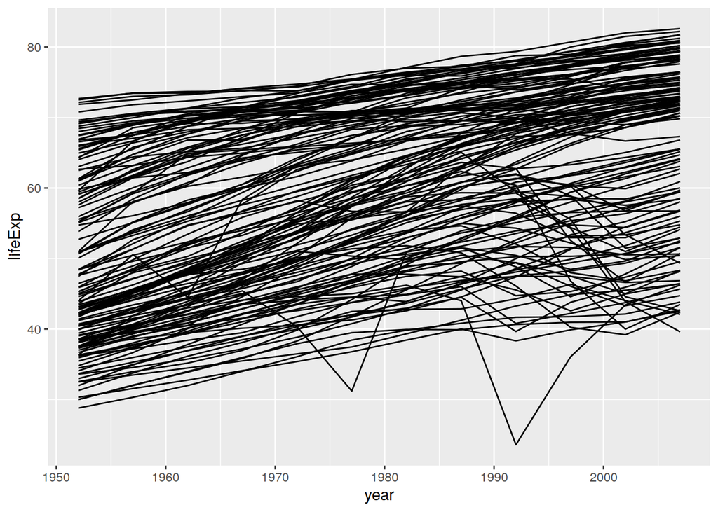

```r
df %>%
  ggplot(aes(x = year, y = lifeExp, group = country))+
  geom_line()
```

ça, c’est ce qu’on appelle un ‘spaghetti plot’ – on n’y comprend rien. On va ajouter des facets et colorier par continent.

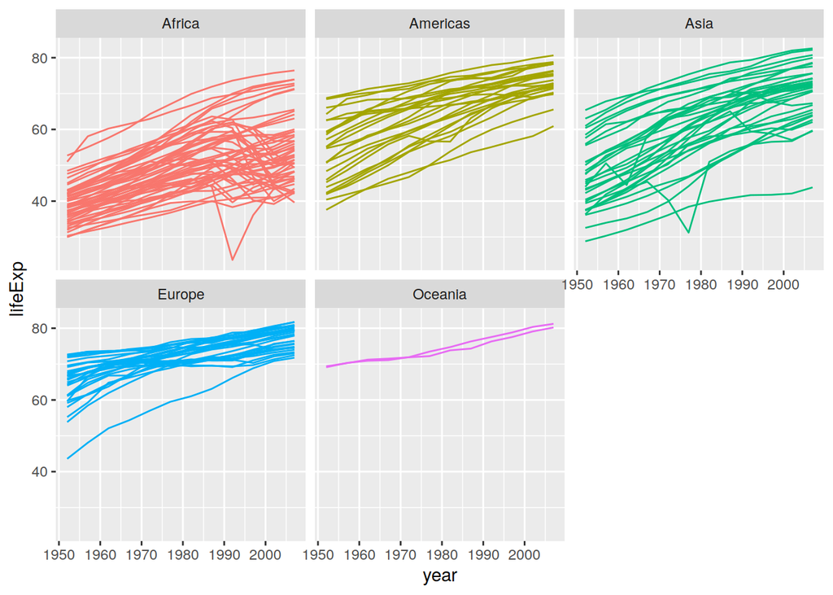

```r
df %>%
  ggplot(aes(x = year, y = lifeExp,
             color = continent, group = country))+
  geom_line()+
  facet_wrap(~continent)+
  theme(legend.position = "none")
```

L’espérance de vie à l’air d’avoir augmenté un peu partout. Mais pourquoi? s’agit-il d’un effet de richesse – plus on est riches, plus long on vit?

On va faire une régression pour cela. On sait comment faire:

```r
df %>%
  lm(lifeExp ~ gdpPercap, data = .) %>%
  tidy()
```

```
## # A tibble: 2 x 5
##   term         estimate std.error statistic   p.value
##   <chr>           <dbl>     <dbl>     <dbl>     <dbl>
## 1 (Intercept) 54.0      0.315         171.  0.
## 2 gdpPercap    0.000765 0.0000258      29.7 3.57e-156
```

cela à l’air très significatif. On va faire un plot en utilisant `augment` pour vérifier de façon visuelle

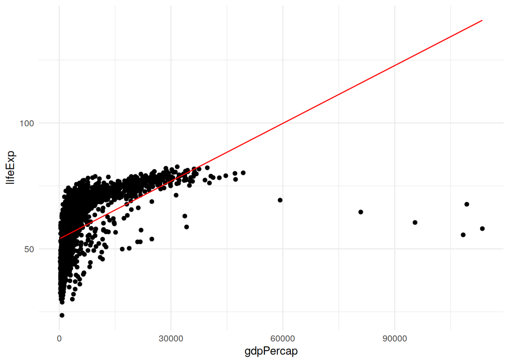

```r
df %>%
  lm(lifeExp ~ gdpPercap, data = .) %>%
  augment() %>%
  ggplot(aes(x = gdpPercap, y = lifeExp))+
  geom_point()+
  geom_line(aes(y = .fitted), color = 'red')+
  theme_minimal()
```

pourquoi le fit est si mauvais? parce que les données contiennent une observation par pays **par an** et dans ce plot on ne tient pas en compte cela.

### régressions par groupe

On peut bien se demander: est-ce que le coefficient de la régression a varié au fil du temps? autrement dit: peut-être dans les années 50 il y avait une forte corrélation entre le PIB et l’augmentation de l’espérance de vie, mais cette corrélation est venue moins dans les années récentes.

Pour répondre à cela il faut faire une régression par an, et après regarder (plotter) les coefficients et leurs intervaux de confiance pour voir si l’effet est toujours bien vivant ou il s’affaiblit. De plus, le faire par continent aiderait. Peut-on faire cela?

Malheureusement, une approche simple et naive (groupez puis faites le lm) ne marche pas.

```r
# ne marche pas -- lm() ne connait pas structure par groupe
# df %>%
#   group_by(year, continent) %>%
#   lm(lifeExp ~ gdpPercap, data = .) %>%
#   tidy()

# ne marche pas, summarise gère des fonctions qui retournent une seule valeur
# df %>%
#   group_by(year, continent) %>%
#   summarise(model = lm(lifeExp ~ gdpPercap, data = .))
```

comment faire?

il faut passer par un `nest`. C’est une fonction qui ‘découpe’ le `data.frame` suivant `group_by()` et met le morceau de data.frame découpé comme s’il était une variable dans le data.frame d’origine.

```r
df %>%
  group_by(year, continent) %>%
  nest() -> nested
```

avec ce ‘nested’ data.frame on peut appliquer un `lm` pour chaque élément, en utilisant chaque découpe de data.frame comme si elle était une variable.

```r
nested %>%
  mutate(model = map(data, ~lm(lifeExp ~ gdpPercap, data = .))) -> model
```

En regardant le nouvel objet crée on se rend compte qu’on a maintenant une nouvelle colonne, “model”, qui contient le modèle. En effet il contient le même contenu qu’un appel à `lm`, mait l’appel a été

1. fait sur une partie des données, et en particulier sur une année/continent, et
2. il est stocké dans une variable.

Maintenant il faut extraire les informations contenues dans le modèle et les stocker dans une nouvelle variable. On peut faire cela avec, par exemple `tidy()`.

```r
model %>%
  mutate(results = map(model, tidy)) -> resultat
```

Si on regarde l’objet obtenu (`result`) on peut voir qu’une colonne ‘result’ a été crée, et qu’ele contient un data.frame entire (le résultat d’un appel à `tidy` si les données n’étaient que celles contenues dans la variable `data` pour chaque ligne du tableau).

Il ne nous reste qu’à *extraire* cette information, en utilisant le verbe complément de `nest()`: `unnest()`:

```r
resultat %>%
  unnest(results) -> final
final
```

```
## # A tibble: 120 x 7
##     year continent term         estimate std.error statistic  p.value
##    <int> <fct>     <chr>           <dbl>     <dbl>     <dbl>    <dbl>
##  1  1952 Asia      (Intercept) 45.8      1.67          27.4  2.59e-23
##  2  1952 Asia      gdpPercap    0.000108 0.0000874      1.24 2.24e- 1
##  3  1957 Asia      (Intercept) 48.7      1.74          28.0  1.44e-23
##  4  1957 Asia      gdpPercap    0.000103 0.0000868      1.19 2.45e- 1
##  5  1962 Asia      (Intercept) 50.8      1.79          28.3  9.92e-24
##  6  1962 Asia      gdpPercap    0.000141 0.000104       1.35 1.87e- 1
##  7  1967 Asia      (Intercept) 53.5      1.78          30.0  1.72e-24
##  8  1967 Asia      gdpPercap    0.000198 0.000118       1.68 1.04e- 1
##  9  1972 Asia      (Intercept) 56.0      1.79          31.4  4.65e-25
## 10  1972 Asia      gdpPercap    0.000156 0.0000871      1.79 8.30e- 2
## # … with 110 more rows
```

et voilà. On a obtenu un objet `final` qui contient une estimation *par ligne* – dans ce cas par année/continent.

on peut maintenant avec aise plotter les résultats et voir si notre idée que la rélation entre PIB et espérance de vie s’estompe avec le temps est soutenue par les données.

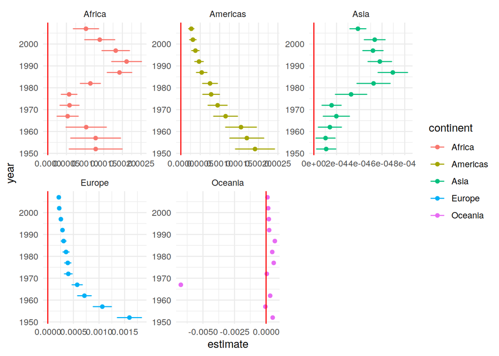

```r
final %>%
  filter(term == "gdpPercap") %>%
  ggplot(aes(x = year, y = estimate, color = continent))+
  geom_errorbar(aes(ymin = estimate - std.error, ymax = estimate + std.error), width = 0.1)+
  geom_point()+
  facet_wrap(~continent, scales = "free")+
  geom_hline(yintercept = 0, color = 'red')+
  coord_flip()+
  theme_minimal()
```

rappel: un point dans ce plot ne répresente pas les données mais une estimation de l’effet du PIB sur l’espérance de vie. L’intuition que la rélation soit moins forte au fil du temps tient bien la route pour l’Europe et les deux amériques; pas pour le reste du monde.

## sommaire de la méthode

1. groupez le data frame
2. `nest()`: une colonne est créée qui contient tout le data.frame rélatif à un groupe
3. appliquer le modèle linéaire en passant par `map()` qui applique une fonction a des données, ligne par ligne
4. utiliser `tidy()` pour extraire les données du modèle en format data.frame et les stocker dans une colonne;
5. `unnest()`
6. les données sont prêtes pour être utilisées de façon *tidy*.

voilà le code qui saute les passage intermédiaires et qui peut donc être reutilisé:

```r
## code dans une seule pipe
df %>%
  group_by(country)       %>% # groupement désiré
  nest()                          %>% # création de la colonne qui contient les découpes de data.fram
  mutate(model = map(data, ~lm(lifeExp ~ gdpPercap, data = .))) %>% # application du modèle ligne par ligne
  mutate(results = map(model, tidy))                            %>% # nettoyage des résultats du modèle
  unnest(results)
```

```
## # A tibble: 284 x 6
##    country     term        estimate std.error statistic      p.value
##    <fct>       <chr>          <dbl>     <dbl>     <dbl>        <dbl>
##  1 Afghanistan (Intercept) 39.3     12.0          3.26  0.00857
##  2 Afghanistan gdpPercap   -0.00224  0.0149      -0.151 0.883
##  3 Albania     (Intercept) 54.0      3.16        17.1   0.0000000101
##  4 Albania     gdpPercap    0.00444  0.000917     4.84  0.000682
##  5 Algeria     (Intercept) 27.4      4.90         5.60  0.000226
##  6 Algeria     gdpPercap    0.00714  0.00106      6.71  0.0000533
##  7 Angola      (Intercept) 41.6      3.91        10.6   0.000000899
##  8 Angola      gdpPercap   -0.00103  0.00104     -0.998 0.342
##  9 Argentina   (Intercept) 52.3      3.60        14.5   0.0000000479
## 10 Argentina   gdpPercap    0.00187  0.000395     4.74  0.000797
## # … with 274 more rows
```

les données sont prêtes à être utilisées.

### exercice

> faites une régression de pop sur year pour chaque continent – cela estime le taux de croissance moyen linéaire sur la période, par continent. Utilisez la méthode `nest` décrite ci-dessus. **Quel continent avait la croissance la plus élevée sur la période?**

```r
df %>%
  group_by(continent)       %>% # groupement désiré
  nest()                          %>% # création de la colonne qui contient les découpes de data.fram
  mutate(model = map(data, ~lm(pop ~ year, data = .))) %>% # application du modèle ligne par ligne
  mutate(results = map(model, tidy))                            %>% # nettoyage des résultats du modèle
  unnest(results)
```

```
## # A tibble: 10 x 6
##    continent term            estimate   std.error statistic  p.value
##    <fct>     <chr>              <dbl>       <dbl>     <dbl>    <dbl>
##  1 Asia      (Intercept) -2660735533. 1185874904.     -2.24 2.54e- 2
##  2 Asia      year            1383064.     599055.      2.31 2.15e- 2
##  3 Europe    (Intercept)  -185725663.  123742758.     -1.50 1.34e- 1
##  4 Europe    year             102498.      62510.      1.64 1.02e- 1
##  5 Africa    (Intercept)  -472771893.   68498152.     -6.90 1.27e-11
##  6 Africa    year             243843.      34602.      7.05 4.87e-12
##  7 Americas  (Intercept)  -784274981.  334870294.     -2.34 1.98e- 2
##  8 Americas  year             408578.     169163.      2.42 1.63e- 2
##  9 Oceania   (Intercept)  -241664546.  146295874.     -1.65 1.13e- 1
## 10 Oceania   year             126567.      73903.      1.71 1.01e- 1
```

# Corrélation

On peut suivre la même démarche pour des corrélations. Une corrélation indique la présence d’une rélation linéaire entre les données. On va à nouveau utiliser le jeu de données `gapminder` et tester la corrélation entre PIB et lifeExp.

## Base R

une corrélation se fait simplement avec `cor()`.

```r
cor(gapminder$lifeExp, gapminder$gdpPercap)
```

```
## [1] 0.5837062
```

par contre si on veut tester la significativité statistique de cette corrélation il faut utiliser `cor.test()`:

```r
objetcorr <- cor.test(gapminder$lifeExp, gapminder$gdpPercap)
```

notez que `cor()` retounre tout simplement une valeur; `cor_test()` retourne en revanche une liste, un objet complexe et avec plusieurs attributs, exactement comme `lm`.

## Tidyverse, juste corrélation

La syntaxe du tidyverse est assez simple parce qu’elle peut utiliser directement `summarise`. Summarise marche avec toute fonction qui prend un vecteur et retourne un nombre.

```r
gapminder %>%
  summarise(correlation = cor(lifeExp, gdpPercap))
```

```
## # A tibble: 1 x 1
##   correlation
##         <dbl>
## 1       0.584
```

Du fait que `cor()` ne retourne qu’une seule valuer, on peut appliquer directement le `group_by()` et tout va bien; par exemple corrélation par continent:

```r
gapminder %>%
  group_by(continent) %>%
  summarise(correlation = cor(lifeExp, gdpPercap))
```

```
## # A tibble: 5 x 2
##   continent correlation
##   <fct>           <dbl>
## 1 Africa          0.426
## 2 Americas        0.558
## 3 Asia            0.382
## 4 Europe          0.781
## 5 Oceania         0.956
```

La corrélation est bcp plus forte pour Europe et Océanie.

## tidyverse, corrélation et test

En revanche si on veut utiliser cor.test pour connaitre la valuer p de notre corrélation, on ne peut pas utiliser directement l’approche naïve – parce que `summarise` ne sait pas quoi faire avec les nombreuses dimensions de l’objet retourné par la fonction `cor.test()`. L’approche naïve ne marche pas:

```r
#gapminder %>%
#  summarise(test = cor.test(lifeExp, gdpPercap))
```

et voilà, R râle parce que `summmarise` s’attend à une seule valeur et en reçoit 9 (et chacune d’entre elles est un objet complexe).

Il faut à nouveau passer par `nest`. Heureusement on a déjà le code, il suffit de changer le `lm` par un `cor.test`:

```r
gapminder %>%
  group_by(continent) %>%
  nest() %>%
  mutate(model = map(data, ~cor.test(.$lifeExp, .$gdpPercap))) %>%
  mutate(result = map(model, tidy)) %>%
  unnest(result)
```

```
## # A tibble: 5 x 11
##   continent data  model estimate statistic  p.value parameter conf.low
##   <fct>     <lis> <lis>    <dbl>     <dbl>    <dbl>     <int>    <dbl>
## 1 Asia      <tib… <hte…    0.382      8.21 3.29e-15       394    0.295
## 2 Europe    <tib… <hte…    0.781     23.6  4.05e-75       358    0.737
## 3 Africa    <tib… <hte…    0.426     11.7  7.60e-29       622    0.359
## 4 Americas  <tib… <hte…    0.558     11.6  5.45e-26       298    0.475
## 5 Oceania   <tib… <hte…    0.956     15.4  2.99e-13        22    0.901
## # … with 3 more variables: conf.high <dbl>, method <chr>,
## #   alternative <chr>
```

et voilà, on a les estimations (elles sont les mêmes que toute à l’heure) mais aussi les valuers p et les intervals de confiance.

### Exercice

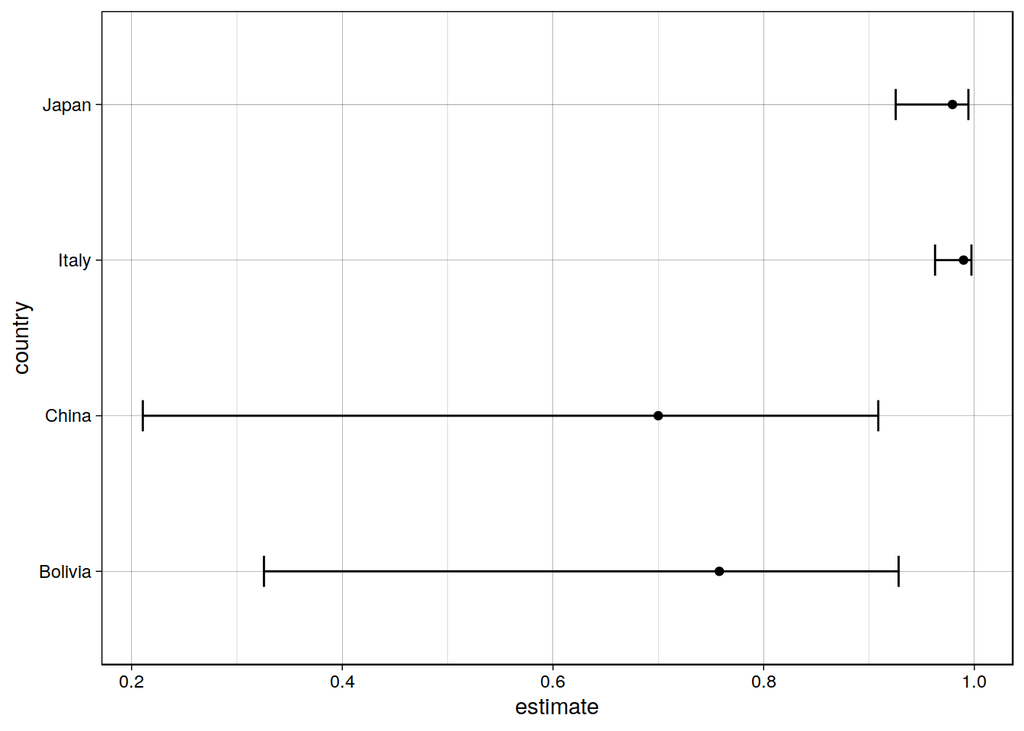

```r
## je lance les corrélations et sauvegarde
gapminder %>%
  group_by(country) %>%
  nest() %>%
  mutate(model = map(data, ~cor.test(.$lifeExp, .$gdpPercap))) %>%
  mutate(result = map(model, tidy)) %>%
  unnest(result) -> correlations

# je fais le plot
correlations %>%
  filter(country %in% c("Italy", "China", "Japan", "Bolivia")) %>%
  ggplot(aes(x = country, y = estimate, ymin = conf.low, ymax = conf.high))+
  geom_point()+
  geom_errorbar(width = 0.2)+
  coord_flip()+
  theme_linedraw()
```

# t-test (et n’importe quel autre test)

le test T à une variable sert à tester si la moyenne d’une variable est significativement différent d’une valeur de référence (par défaut: 0); à deux variables à tester si la moyenne d’une variable est statistiquement différente de l’autre.

On va tester une quesiton:

1. peut on dire que l’espérance de vie à la naissance est > 60 dans le monde?

## Base R

```r
t.test(gapminder$lifeExp, mu = 60, alternative = "greater")
```

```
##
##  One Sample t-test
##
## data:  gapminder$lifeExp
## t = -1.6795, df = 1703, p-value = 0.9534
## alternative hypothesis: true mean is greater than 60
## 95 percent confidence interval:
##  58.95946      Inf
## sample estimates:
## mean of x
##  59.47444
```

Mais peut-être que cet âge de 60 a été dépassé à des temps différents dans des pays différents.

Si on ne voulait qu’afficher l’âge moyen par continent et année, il suffit un appel à `summarise`:

```r
gapminder %>%
  group_by(continent, year) %>%
  summarise(meanlifeexp = mean(lifeExp, na.rm = T))
```

```
## # A tibble: 60 x 3
## # Groups:   continent [5]
##    continent  year meanlifeexp
##    <fct>     <int>       <dbl>
##  1 Africa     1952        39.1
##  2 Africa     1957        41.3
##  3 Africa     1962        43.3
##  4 Africa     1967        45.3
##  5 Africa     1972        47.5
##  6 Africa     1977        49.6
##  7 Africa     1982        51.6
##  8 Africa     1987        53.3
##  9 Africa     1992        53.6
## 10 Africa     1997        53.6
## # … with 50 more rows
```

mais si on veut tester la différence par rapport à 60 avec in test T il faut passer par un `nest()`, comme on a vu pour le `lm` et la `cor`relation:

```r
## code dans une seule pipe
gapminder %>%
  group_by(continent, year) %>%
  nest() %>%
  mutate(ttest = map(data, ~t.test(.$lifeExp, mu = 60, alternative = "greater"))) %>%
  mutate(result = map(ttest, tidy)) %>%
  unnest(result) -> ttest_gap
```

et avec un plot on obtient la réponse:

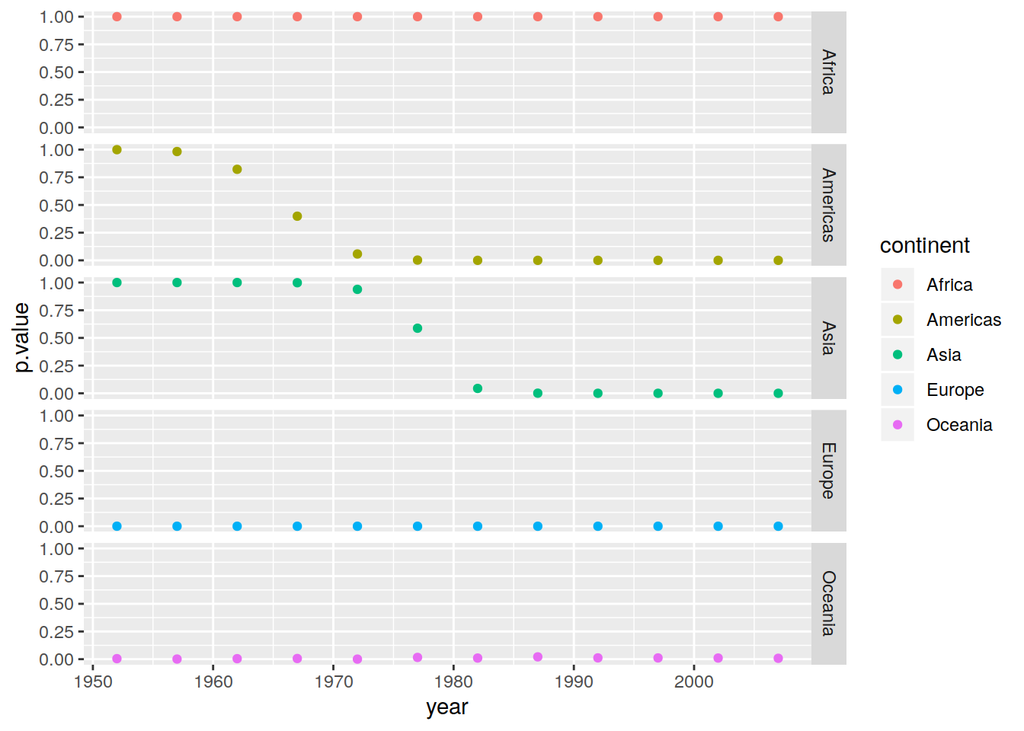

```r
ttest_gap %>%
  ggplot(aes(x = year, y = p.value, color = continent))+
  geom_point()+
  facet_grid(continent~.)
```

réponse: pour l’Afrique, l’espérance de vie à la naissance n’a jamais été supérieure à 60 (les valeurs p sont toujours 1, ce qui indique qu’on ne peut pas rejeter l’hypothèse que la moyenne est inférieure à 60); pour Europe et Océanie, la moyenne a toujours été supérieure; pour Amérique et Asie, la transtition par 60 s’est effectuée pendant la periode d’observation.